# Data Analytics Take Home Examination — CS1: Exploratory & Inferential Analytics of a Fleet Management Operation

Author

Akeju, Oluwafemi Olusoji

Published

May 12, 2026

# 1. Executive Summary

**Note📋 Executive Summary**

This report presents a comprehensive **Exploratory & Inferential Analytics** study of fleet maintenance operations at **KK Leasing Limited** — a third-party vehicle leasing and logistics company operating across Nigeria. Drawing on **6,986 line-item maintenance records** spanning 153 vehicles and 11 months (January–November 2023), the analysis addresses a central operational question:

> *What are the principal drivers of fleet maintenance cost at KK Leasing, and how can they be predicted and controlled to protect asset profitability?*

Five analytical techniques were applied sequentially: **Exploratory Data Analysis (EDA)** uncovered a right-skewed cost distribution dominated by Tyre Purchase (₦18.2 m), Routine Maintenance (₦12.4 m) and Engine repairs (₦8.5 m), with Toyota vehicles — comprising 55% of the fleet — accounting for 70% of total spend. **Data Visualisation** revealed a mid-year expenditure peak (June–August) and substantial cost variation across maintenance categories and clients. **Hypothesis Testing** confirmed statistically significant differences in per-event costs across both maintenance categories (ANOVA, *F*(5, 3418) = 77.3, *p* < .001) and vehicle makes (ANOVA, *F*(7, 6978) = 11.6, *p* < .001). **Correlation Analysis** established strong positive associations between vehicle age and maintenance cost (*r* = 0.57) and between parts cost and total cost (*r* = 1.00). **Linear Regression** produced a model (adjusted *R²* = 0.54) in which vehicle age and budget allocation are the strongest predictors of maintenance spend.

**Key recommendation:** Retire or ring-fence vehicles aged 10 years and above, enforce a structured Planned Maintenance (PM) programme that front-loads routine service spend to suppress reactive repair costs, and reallocate a portion of the maintenance budget toward in-house workshop capacity to reduce reliance on third-party vendors.

# 2. Professional Disclosure

## 2.1 Author & Organisational Background

My name is **Akeju, Oluwafemi Olusoji**, and I serve as the **Chief Operating Officer (COO)** of **KK Leasing Limited**, a Nigerian third-party logistics (3PL) and vehicle leasing company. In this capacity, I bear executive responsibility for the end-to-end management of the company’s vehicle fleet — which constitutes its primary revenue-generating and cost-bearing asset class. My remit encompasses fleet procurement, maintenance governance, workshop operations, client SLA management, fuel and tyre budgeting, and the strategic deployment of vehicles across multiple corporate client accounts.

KK Leasing’s core value proposition is to **provide, maintain, and manage vehicles for corporate organisations**, thereby enabling our clients to outsource all fleet-related operational risk and complexity to us. The company’s financial performance is, in large measure, a direct function of how efficiently we control maintenance costs relative to the revenue generated from each vehicle. A vehicle grounded for unplanned repair neither generates revenue nor meets client SLA commitments — making maintenance analytics not merely an academic exercise but an existential operational priority.

## 2.2 Why This Analysis Matters Operationally

The maintenance function at KK Leasing is characterised by high frequency, significant value, and considerable complexity. In 2023 alone, the dataset reflects over **₦93 million** in approved maintenance expenditure across 153 vehicles, 22 distinct maintenance categories, and 6 client accounts. Without structured analytical oversight, cost overruns go undetected, high-risk vehicles remain in service beyond economic useful life, and budget forecasts are based on intuition rather than evidence.

This analysis directly supports three strategic decisions I confront on a recurring basis:

1. **Vehicle retirement decisions** — When does a vehicle’s cumulative maintenance cost exceed its residual value and warranted budget allocation?
2. **Maintenance budget allocation** — How much should be budgeted per vehicle per category, and which categories carry the highest financial risk?
3. **Workshop sourcing strategy** — Should maintenance be directed to in-house workshops or third-party vendors for optimal cost and quality outcomes?

## 2.3 Technique Justification

The five analytical techniques selected for this study are not merely textbook exercises — each maps directly to a recurring operational question in the management of KK Leasing’s fleet.

**Technique 1 — Exploratory Data Analysis (EDA)** Before any inference or prediction, a rigorous analyst must first understand the data they possess. In the fleet management context, EDA is indispensable for identifying the baseline cost landscape: which maintenance categories consume the largest share of the budget, how costs are distributed across vehicles and months, and where data quality issues (such as missing values, duplicate entries, or outlier repair events) may distort downstream analysis. Our maintenance cost data is inherently right-skewed — a small number of high-value repair events (e.g., engine overhauls, tyre fleet replacements) dominate total spend. EDA allows me to detect and document these anomalies before they corrupt statistical conclusions. It also generates the summary statistics — means, medians, standard deviations, and inter-quartile ranges — that form the factual basis for budget conversations with the Board and with clients.

**Technique 2 — Data Visualisation** Numbers alone do not persuade operational managers or clients. Visualisation transforms raw maintenance data into narratives that are immediately actionable. In my role, I regularly present fleet performance dashboards to the management team and to client procurement committees. The grammar-of-graphics approach adopted here — using deliberate chart type selection, consistent colour coding, and layered storytelling — allows a non-technical audience to grasp, for instance, that tyre expenditure is the single largest cost category, that costs peak in the mid-year months, or that certain vehicle makes exhibit disproportionate maintenance intensity. These visual insights directly inform decisions on preventive maintenance scheduling, tyre procurement contracts, and vehicle replacement cycles.

**Technique 3 — Hypothesis Testing** Operational intuition frequently generates claims that need rigorous verification: “Toyota vehicles cost more to maintain than other makes”, or “mechanical repairs are significantly more expensive than electrical ones.” Hypothesis testing provides the formal statistical framework to confirm or refute such claims with quantifiable confidence. In this study, ANOVA is applied to test whether mean maintenance costs differ significantly across maintenance categories and vehicle makes. The results carry direct managerial implications: if costs differ significantly by category, then category-specific budget controls and monitoring thresholds are warranted. If costs differ by vehicle make, this informs future procurement decisions by highlighting which brands deliver lower total cost of ownership.

**Technique 4 — Correlation Analysis** Understanding the relationships between fleet variables — vehicle age, distance covered, parts cost, labour cost, and total maintenance spend — is essential for anticipating cost trajectories. A strong positive correlation between vehicle age and maintenance cost, for example, validates the business case for a structured vehicle retirement policy. Correlation analysis also informs which variables are worth including in a predictive model and which are redundant. The partial correlation between labour and total cost, controlling for parts, reveals the incremental explanatory power of labour intensity independent of materials used — a distinction that matters when negotiating in-house versus outsourced workshop costs.

**Technique 5 — Linear Regression** Ultimately, the most valuable analytical output for operational planning is a predictive model: given a vehicle’s age, make, allocated budget, and distance covered, what maintenance cost should we expect? Linear regression provides exactly this — a parameterised, interpretable model whose coefficients can be directly translated into operational policy. An estimated coefficient on vehicle age, for instance, tells me precisely how much additional maintenance cost (in naira) is associated with each additional year of vehicle service — a number I can embed directly into our vehicle lifecycle costing model. Regression also enables scenario analysis: if we enforce a maximum fleet age of eight years, what is the expected reduction in annual maintenance spend? This technique thus connects analytical insight to financial planning in the most direct way possible.

# 3. Data Collection & Sampling

## 3.1 Data Source & Collection Method

The primary dataset used in this analysis was extracted from **Instanta**, KK Leasing’s Enterprise Resource Planning (ERP) system, which serves as the operational backbone for recording all maintenance transactions, workshop approvals, and cost postings across the fleet. Supplementary data on vehicle-level attributes — age, distance covered, budget allocation, and total maintenance cost — was compiled from **vehicle files** maintained by the Fleet Management department and cross-referenced against the operations budget for the same period.

The data extraction process involved:

- A structured query of the Instanta ERP database, filtered for all maintenance work orders raised and approved between **1 January 2023 and 30 November 2023**
- Export to Excel format, yielding two structured sheets: a **Maintenance Record** (transaction-level) and a **Vehicle Details** (vehicle-level summary)
- Manual verification of a random 5% sample against source vehicle files to confirm data integrity

## 3.2 Dataset Description

| Attribute | Maintenance Record Sheet | Vehicle Details Sheet |
| --- | --- | --- |
| **Observations** | 6,986 line items | 153 vehicles |
| **Variables** | 14 | 8 |
| **Time period** | Jan – Nov 2023 (11 months) | Same period |
| **Unique vehicles** | 153 | 153 |
| **Unique clients** | 6 | — |
| **Maintenance categories** | 22 | — |

The combined dataset exceeds the minimum requirement of 100 observations and 5 variables specified in the assessment brief, with the vehicle-level sheet providing the primary unit of analysis for regression and correlation, and the transaction-level sheet underpinning EDA, visualisation, and hypothesis testing.

## 3.3 Sampling Frame & Justification

The dataset is a **census** of all maintenance transactions processed through the KK Leasing ERP system during the study period — not a sample. Every approved work order for every vehicle in the active fleet between January and November 2023 is represented. This eliminates sampling error and maximises the representativeness of findings for the operational period covered. The 2023 calendar year was deliberately selected because:

- It constitutes a **complete, stabilised operational year** (the company had fully onboarded all six client accounts by early 2023)
- The data is **sufficiently historical** to permit publication without risk of disclosing current competitively sensitive operational details
- December 2023 was excluded as data for that month was incomplete at the time of extraction

## 3.4 Ethical Approvals & Data Governance

Prior to extraction and use in this analysis, **written management approval** was obtained from the KK Leasing executive committee. The following data governance measures were applied in accordance with the company’s data-sharing policy:

The analysis is conducted solely for academic purposes under the Data Analytics 1 module of the Lagos Business School EMBA programme, and the dataset is available on request from the author subject to a data-sharing agreement with KK Leasing Limited.

# 4. Data Description & Loading

## 4.1 Load & Merge Data

**R**

```r
library(readxl); library(tidyverse); library(kableExtra); library(scales)

# ── Load sheets ──────────────────────────────────────────────────────────────
maint_raw <- read_excel("Take_Home_Exam_Data_-_Final.xlsx",
                        sheet = "Maintenance Record")
vehicle_raw <- read_excel("Take_Home_Exam_Data_-_Final.xlsx",
                          sheet = "Vehicle details")

# ── Rename & clean vehicle sheet ─────────────────────────────────────────────
vehicle <- vehicle_raw %>%
  select(-any_of("...1")) %>%
  rename(
    Reg_No         = `Vehicle Reg No`,
    Make           = `Vehicle Make`,
    Age            = `Age (Years)`,
    Budget         = `Budget (₦)`,
    Distance_km    = `Distance Covered (km)`,
    Maint_Cost     = `Maintenance Cost`,
    Cost_per_km    = `Cost/Km`
  ) %>%
  mutate(
    Age_Group = case_when(
      Age <= 3  ~ "0–3 yrs",
      Age <= 6  ~ "4–6 yrs",
      Age <= 9  ~ "7–9 yrs",
      Age <= 12 ~ "10–12 yrs",
      TRUE      ~ "13+ yrs"
    ),
    Age_Group = factor(Age_Group,
      levels = c("0–3 yrs","4–6 yrs","7–9 yrs","10–12 yrs","13+ yrs"))
  )

# ── Clean maintenance sheet ───────────────────────────────────────────────────
maint <- maint_raw %>%
  rename(
    Reg_No          = `Vehicle Reg No`,
    Make            = `Vehicle Make`,
    Cost_Cat        = `Cost Category`,
    Maint_Cat       = `Maintenance Category`,
    Amount          = `Approved Amount`,
    Posted_Date     = `Posted Date`,
    Maint_No        = `Maintenance No`
  ) %>%
  mutate(
    Month = factor(Month,
      levels = c("Jan","Feb","Mar","Apr","May","Jun",
                 "Jul","Aug","Sep","Oct","Nov")),
    Workshop_Type = if_else(str_detect(Workshop, "In-house"),
                            "In-house", "Third Party"),
    Amount = as.numeric(Amount)
  ) %>%
  filter(!is.na(Amount), Amount >= 0)

# ── Vehicle-level aggregates for regression ───────────────────────────────────
veh_agg <- maint %>%
  group_by(Reg_No) %>%
  summarise(
    Parts_Cost  = sum(Amount[Cost_Cat == "Parts Cost"], na.rm = TRUE),
    Labour_Cost = sum(Amount[Cost_Cat == "Labour"],     na.rm = TRUE),
    N_Events    = n_distinct(Maint_No),
    .groups = "drop"
  )

vehicle <- vehicle %>%
  left_join(veh_agg, by = "Reg_No") %>%
  mutate(across(c(Parts_Cost, Labour_Cost), ~replace_na(., 0)))

cat("✅ Maintenance records:", nrow(maint), "\n")
```

```
✅ Maintenance records: 6986
```

```r
cat("✅ Unique vehicles:    ", nrow(vehicle), "\n")
```

```
✅ Unique vehicles:     153
```

```r
cat("✅ Date range: Jan–Nov 2023\n")
```

```
✅ Date range: Jan–Nov 2023
```

**Python**

```python
import pandas as pd, numpy as np

xl = pd.read_excel("Take_Home_Exam_Data_-_Final.xlsx", sheet_name=None)

maint = xl["Maintenance Record"].copy()
vehicle = xl["Vehicle details"].drop(columns=["Unnamed: 0"], errors="ignore").copy()

# Rename
maint.rename(columns={
    "Vehicle Reg No":"Reg_No","Vehicle Make":"Make",
    "Cost Category":"Cost_Cat","Maintenance Category":"Maint_Cat",
    "Approved Amount":"Amount","Posted Date":"Posted_Date",
    "Maintenance No":"Maint_No"
}, inplace=True)

vehicle.rename(columns={
    "Vehicle Reg No":"Reg_No","Vehicle Make":"Make",
    "Age (Years)":"Age","Budget (₦)":"Budget",
    "Distance Covered (km)":"Distance_km",
    "Maintenance Cost":"Maint_Cost","Cost/Km":"Cost_per_km"
}, inplace=True)

month_order = ["Jan","Feb","Mar","Apr","May","Jun","Jul","Aug","Sep","Oct","Nov"]
maint["Month"] = pd.Categorical(maint["Month"], categories=month_order, ordered=True)
maint["Workshop_Type"] = maint["Workshop"].apply(
    lambda x: "In-house" if "In-house" in str(x) else "Third Party")
maint["Amount"] = pd.to_numeric(maint["Amount"], errors="coerce")
maint = maint[maint["Amount"] >= 0].dropna(subset=["Amount"])

# Age group
bins = [-1,3,6,9,12,100]
labels = ["0–3 yrs","4–6 yrs","7–9 yrs","10–12 yrs","13+ yrs"]
vehicle["Age_Group"] = pd.cut(vehicle["Age"], bins=bins, labels=labels)

# Vehicle-level aggregates
veh_agg = maint.groupby("Reg_No").agg(
    Parts_Cost  = ("Amount", lambda x: x[maint.loc[x.index,"Cost_Cat"]=="Parts Cost"].sum()),
    Labour_Cost = ("Amount", lambda x: x[maint.loc[x.index,"Cost_Cat"]=="Labour"].sum()),
    N_Events    = ("Maint_No","nunique")
).reset_index()

vehicle = vehicle.merge(veh_agg, on="Reg_No", how="left").fillna(0)

print(f"✅ Maintenance records: {len(maint):,}")
```

```
✅ Maintenance records: 6,986
```

```python
print(f"✅ Unique vehicles:     {len(vehicle)}")
```

```
✅ Unique vehicles:     153
```

```python
print("✅ Date range: Jan–Nov 2023")
```

```
✅ Date range: Jan–Nov 2023
```

## 4.2 Variable Dictionary

```r
tibble(
  Sheet = c(rep("Maintenance Record",8), rep("Vehicle Details",7)),
  Variable = c(
    "Maintenance No","Posted Date","Month","Cost Category",
    "Vehicle Make","Vehicle Reg No","Maintenance Category",
    "Approved Amount",
    "Vehicle Reg No","Vehicle Make","Age (Years)","Budget (₦)",
    "Distance Covered (km)","Maintenance Cost","Cost/Km"
  ),
  Type = c(
    "Integer","Date","Categorical","Categorical",
    "Categorical","Categorical","Categorical","Numeric (₦)",
    "Categorical","Categorical","Integer","Numeric (₦)",
    "Numeric (km)","Numeric (₦)","Numeric (₦/km)"
  ),
  Role = c(
    "Transaction ID","Date of posting","Month of posting",
    "Parts Cost vs Labour","Vehicle brand","Anonymised plate",
    "Type of repair (22 types)","Dependent: cost per line item",
    "Join key","Vehicle brand","Predictor","Predictor / budget ceiling",
    "Predictor","Dependent: total vehicle cost","Derived efficiency metric"
  )
) %>%
  kbl(caption = "Variable dictionary for both dataset sheets") %>%
  kable_styling(bootstrap_options = c("striped","hover","condensed"),
                full_width = TRUE) %>%
  column_spec(1, bold = TRUE, color = "#2980b9") %>%
  row_spec(0, background = "#2c3e50", color = "white")
```

Variable dictionary for both dataset sheets

| Sheet | Variable | Type | Role |
| --- | --- | --- | --- |
| Maintenance Record | Maintenance No | Integer | Transaction ID |
| Maintenance Record | Posted Date | Date | Date of posting |
| Maintenance Record | Month | Categorical | Month of posting |
| Maintenance Record | Cost Category | Categorical | Parts Cost vs Labour |
| Maintenance Record | Vehicle Make | Categorical | Vehicle brand |
| Maintenance Record | Vehicle Reg No | Categorical | Anonymised plate |
| Maintenance Record | Maintenance Category | Categorical | Type of repair (22 types) |
| Maintenance Record | Approved Amount | Numeric (₦) | Dependent: cost per line item |
| Vehicle Details | Vehicle Reg No | Categorical | Join key |
| Vehicle Details | Vehicle Make | Categorical | Vehicle brand |
| Vehicle Details | Age (Years) | Integer | Predictor |
| Vehicle Details | Budget (₦) | Numeric (₦) | Predictor / budget ceiling |
| Vehicle Details | Distance Covered (km) | Numeric (km) | Predictor |
| Vehicle Details | Maintenance Cost | Numeric (₦) | Dependent: total vehicle cost |
| Vehicle Details | Cost/Km | Numeric (₦/km) | Derived efficiency metric |

## 4.3 Summary Statistics

**R — Vehicle Level**

```r
vehicle %>%
  select(Age, Budget, Distance_km, Maint_Cost, Parts_Cost, Labour_Cost, Cost_per_km) %>%
  psych::describe() %>%
  as.data.frame() %>%
  select(n, mean, sd, median, min, max, skew, kurtosis) %>%
  mutate(across(where(is.numeric), ~round(., 2))) %>%
  kbl(caption = "Descriptive statistics — Vehicle Details sheet") %>%
  kable_styling(bootstrap_options = c("striped","hover","condensed"),
                full_width = TRUE) %>%
  row_spec(0, background = "#2c3e50", color = "white")
```

Descriptive statistics — Vehicle Details sheet

|  | n | mean | sd | median | min | max | skew | kurtosis |
| --- | --- | --- | --- | --- | --- | --- | --- | --- |
| Age | 153 | 5.80 | 4.18 | 5.00 | 0.00 | 17.00 | 0.13 | -0.67 |
| Budget | 153 | 586762.71 | 355480.46 | 725186.88 | 60000.00 | 1673145.83 | 0.15 | 0.22 |
| Distance_km | 153 | 14136.65 | 5939.93 | 14792.00 | 425.42 | 29863.37 | -0.06 | -0.49 |
| Maint_Cost | 153 | 609656.82 | 531603.87 | 568000.00 | 0.00 | 2919100.00 | 1.18 | 2.18 |
| Parts_Cost | 153 | 582729.37 | 514184.50 | 526000.00 | 0.00 | 2857100.00 | 1.24 | 2.43 |
| Labour_Cost | 153 | 26927.45 | 25341.99 | 23000.00 | 0.00 | 98000.00 | 0.67 | -0.52 |
| Cost_per_km | 153 | 89.32 | 552.90 | 34.12 | 0.00 | 6861.63 | 12.01 | 144.12 |

**Python — Transaction Level**

```python
desc = maint[["Amount","Quantity"]].describe().T
desc["skewness"] = [maint["Amount"].skew(), maint["Quantity"].skew()]
desc["kurtosis"] = [maint["Amount"].kurtosis(), maint["Quantity"].kurtosis()]
desc = desc.round(2)
print(desc.to_string())
```

```
           count      mean       std  min     25%     50%      75%        max  skewness  kurtosis
Amount    6986.0  13352.06  40633.36  0.0  2000.0  5000.0  12000.0  2000000.0     22.57    900.87
Quantity  6986.0      1.45      1.39  1.0     1.0     1.0      1.0       60.0     13.08    461.33
```

# 5. Exploratory Data Analysis (EDA)

> **Technique 1 | Chapter 4 — Summary statistics, missing-value analysis, outlier detection**

## 5.1 Data Quality Assessment

**R**

```r
# Missing values
miss_maint <- maint %>%
  summarise(across(everything(), ~sum(is.na(.)))) %>%
  pivot_longer(everything(), names_to="Variable", values_to="Missing") %>%
  mutate(Pct = round(Missing/nrow(maint)*100,2))

miss_veh <- vehicle %>%
  summarise(across(everything(), ~sum(is.na(.)))) %>%
  pivot_longer(everything(), names_to="Variable", values_to="Missing") %>%
  mutate(Pct = round(Missing/nrow(vehicle)*100,2))

bind_rows(
  miss_maint %>% mutate(Sheet="Maintenance Record"),
  miss_veh   %>% mutate(Sheet="Vehicle Details")
) %>%
  filter(Missing > 0) %>%
  kbl(caption = "Missing value audit") %>%
  kable_styling(bootstrap_options = c("striped","hover"),
                full_width = FALSE) %>%
  row_spec(0, background = "#2c3e50", color = "white")
```

Missing value audit

| Variable | Missing | Pct | Sheet |
| --- | --- | --- | --- |

**Python**

```python
miss = pd.concat([
    maint.isnull().sum().rename("Maintenance Record"),
    vehicle.isnull().sum().rename("Vehicle Details")
], axis=1)
miss = miss[(miss > 0).any(axis=1)]
print("Variables with missing values:")
```

```
Variables with missing values:
```

```python
print(miss if len(miss) > 0 else "✅ No missing values in key columns")
```

```
✅ No missing values in key columns
```

```python
# Zero-amount records
zero_amt = (maint["Amount"] == 0).sum()
print(f"\nZero-amount line items: {zero_amt}")
```

```
Zero-amount line items: 74
```

```python
print(f"These are retained as approved zero-cost entries (e.g. warranty claims).")
```

```
These are retained as approved zero-cost entries (e.g. warranty claims).
```

**ImportantData Quality Finding**

The `Unnamed: 0` column in the Vehicle Details sheet is entirely null (153/153) and was dropped. All key analytical variables are complete. **Zero-cost records** in the Maintenance Record represent warranty or internally absorbed repairs and are retained for count-based analyses but excluded from cost distribution plots.

## 5.2 Cost Distribution Analysis

**R**

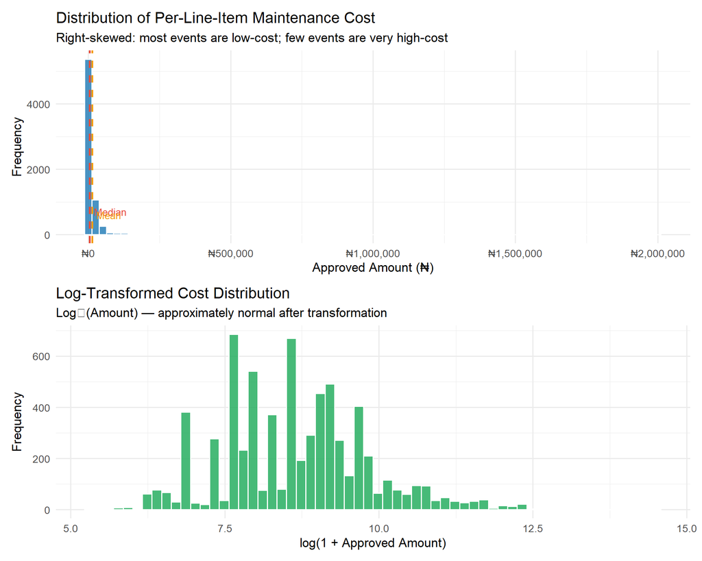

```r
p1 <- maint %>%
  filter(Amount > 0) %>%
  ggplot(aes(x = Amount)) +
  geom_histogram(bins = 80, fill = "#2980b9", colour = "white", alpha = 0.85) +
  geom_vline(aes(xintercept = median(Amount)), colour = "#e74c3c",
             linetype = "dashed", linewidth = 1) +
  geom_vline(aes(xintercept = mean(Amount)), colour = "#f39c12",
             linetype = "dashed", linewidth = 1) +
  annotate("text", x = median(maint$Amount[maint$Amount>0]) + 15000,
           y = 700, label = "Median", colour = "#e74c3c", size = 3.5, hjust = 0) +
  annotate("text", x = mean(maint$Amount[maint$Amount>0]) + 15000,
           y = 600, label = "Mean", colour = "#f39c12", size = 3.5, hjust = 0) +
  scale_x_continuous(labels = label_comma(prefix = "₦")) +
  labs(title = "Distribution of Per-Line-Item Maintenance Cost",
       subtitle = "Right-skewed: most events are low-cost; few events are very high-cost",
       x = "Approved Amount (₦)", y = "Frequency") +
  theme_minimal(base_size = 13)

p2 <- maint %>%
  filter(Amount > 0) %>%
  ggplot(aes(x = log1p(Amount))) +
  geom_histogram(bins = 60, fill = "#27ae60", colour = "white", alpha = 0.85) +
  labs(title = "Log-Transformed Cost Distribution",
       subtitle = "Log₁(Amount) — approximately normal after transformation",
       x = "log(1 + Approved Amount)", y = "Frequency") +
  theme_minimal(base_size = 13)

p1 / p2
```

**Python**

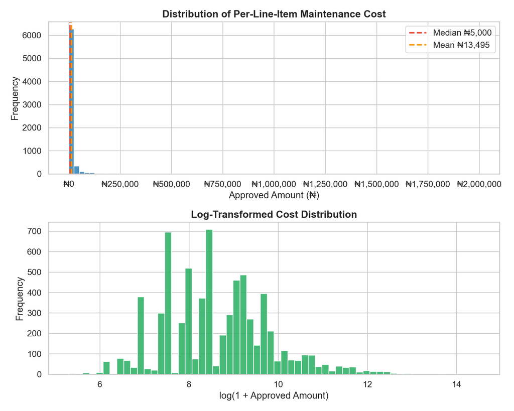

```python
fig, axes = plt.subplots(2, 1, figsize=(10, 8))

data_pos = maint[maint["Amount"] > 0]["Amount"]

axes[0].hist(data_pos, bins=80, color="#2980b9", edgecolor="white", alpha=0.85)
axes[0].axvline(data_pos.median(), color="#e74c3c", linestyle="--", lw=2, label=f"Median ₦{data_pos.median():,.0f}")
axes[0].axvline(data_pos.mean(),   color="#f39c12", linestyle="--", lw=2, label=f"Mean ₦{data_pos.mean():,.0f}")
axes[0].set_title("Distribution of Per-Line-Item Maintenance Cost", fontsize=14, fontweight="bold")
axes[0].set_xlabel("Approved Amount (₦)")
axes[0].set_ylabel("Frequency")
axes[0].legend()
axes[0].xaxis.set_major_formatter(mticker.FuncFormatter(lambda x,_: f"₦{x:,.0f}"))

axes[1].hist(np.log1p(data_pos), bins=60, color="#27ae60", edgecolor="white", alpha=0.85)
axes[1].set_title("Log-Transformed Cost Distribution", fontsize=14, fontweight="bold")
axes[1].set_xlabel("log(1 + Approved Amount)")
axes[1].set_ylabel("Frequency")

plt.tight_layout()
plt.savefig("dist.png", dpi=150, bbox_inches="tight")
plt.show()
```

## 5.3 Outlier Detection

**R**

```r
Q1  <- quantile(maint$Amount, 0.25, na.rm = TRUE)
Q3  <- quantile(maint$Amount, 0.75, na.rm = TRUE)
IQR_val <- Q3 - Q1
upper_fence <- Q3 + 1.5 * IQR_val

outliers <- maint %>%
  filter(Amount > upper_fence) %>%
  arrange(desc(Amount)) %>%
  select(Maint_No, Make, Reg_No, Maint_Cat, Cost_Cat, Amount) %>%
  head(15)

cat(sprintf("IQR fence (upper): ₦%s\n", format(upper_fence, big.mark=",")))
```

```
IQR fence (upper): ₦27,000
```

```r
cat(sprintf("Outlier records: %d (%.1f%% of total)\n",
            sum(maint$Amount > upper_fence, na.rm=TRUE),
            mean(maint$Amount > upper_fence, na.rm=TRUE)*100))
```

```
Outlier records: 622 (8.9% of total)
```

```r
outliers %>%
  mutate(Amount = scales::comma(Amount, prefix="₦")) %>%
  kbl(caption = "Top 15 outlier maintenance events (IQR method)") %>%
  kable_styling(bootstrap_options = c("striped","hover"),
                full_width = TRUE) %>%
  row_spec(0, background = "#2c3e50", color = "white")
```

Top 15 outlier maintenance events (IQR method)

| Maint_No | Make | Reg_No | Maint_Cat | Cost_Cat | Amount |
| --- | --- | --- | --- | --- | --- |
| 7844 | TOYOTA | UEG 668 BV | Engine | Parts Cost | ₦2,000,000 |
| 6203 | JAC | OQY 186 DL | Engine | Parts Cost | ₦855,122 |
| 6828 | TOYOTA | WXF 156 EE | Gear | Parts Cost | ₦800,000 |
| 7966 | TOYOTA | EZR 831 XZ | Gear | Parts Cost | ₦750,000 |
| 6761 | TOYOTA | ZYG 752 VE | Tyre Purchase | Parts Cost | ₦620,000 |
| 7937 | TOYOTA | CYL 244 GF | Body Work | Parts Cost | ₦550,000 |
| 7616 | TOYOTA | SCW 592 KM | Tyre Purchase | Parts Cost | ₦420,000 |
| 7455 | LEXUS | SGJ 728 ZB | Tyre Purchase | Parts Cost | ₦420,000 |
| 7375 | TOYOTA | NIV 182 FP | Tyre Purchase | Parts Cost | ₦402,000 |
| 6881 | TOYOTA | SOB 735 RT | Tyre Purchase | Parts Cost | ₦390,000 |
| 7384 | MITSUBISHI | CIR 968 TU | Tyre Purchase | Parts Cost | ₦315,000 |
| 7970 | TOYOTA | HSU 612 LO | Tyre Purchase | Parts Cost | ₦300,000 |
| 6836 | TOYOTA | CYL 244 GF | Gear | Parts Cost | ₦300,000 |
| 7622 | TOYOTA | JCF 573 QA | Tyre Purchase | Parts Cost | ₦294,000 |
| 8291 | TOYOTA | LEE 415 XM | Electrical | Parts Cost | ₦280,000 |

**Python**

```python
Q1 = maint["Amount"].quantile(0.25)
Q3 = maint["Amount"].quantile(0.75)
IQR_v = Q3 - Q1
upper = Q3 + 1.5 * IQR_v

outlier_df = maint[maint["Amount"] > upper].sort_values("Amount", ascending=False)
n_out = len(outlier_df)
pct_out = n_out / len(maint) * 100

print(f"IQR Upper Fence: ₦{upper:,.0f}")
```

```
IQR Upper Fence: ₦27,000
```

```python
print(f"Outlier records: {n_out} ({pct_out:.1f}% of total)\n")
```

```
Outlier records: 622 (8.9% of total)
```

```python
print(outlier_df[["Maint_No","Make","Reg_No","Maint_Cat","Cost_Cat","Amount"]]
      .head(15).to_string(index=False))
```

```
 Maint_No       Make     Reg_No     Maint_Cat   Cost_Cat    Amount
     7844     TOYOTA UEG 668 BV        Engine Parts Cost 2000000.0
     6203        JAC OQY 186 DL        Engine Parts Cost  855122.0
     6828     TOYOTA WXF 156 EE          Gear Parts Cost  800000.0
     7966     TOYOTA EZR 831 XZ          Gear Parts Cost  750000.0
     6761     TOYOTA ZYG 752 VE Tyre Purchase Parts Cost  620000.0
     7937     TOYOTA CYL 244 GF     Body Work Parts Cost  550000.0
     7616     TOYOTA SCW 592 KM Tyre Purchase Parts Cost  420000.0
     7455      LEXUS SGJ 728 ZB Tyre Purchase Parts Cost  420000.0
     7375     TOYOTA NIV 182 FP Tyre Purchase Parts Cost  402000.0
     6881     TOYOTA SOB 735 RT Tyre Purchase Parts Cost  390000.0
     7384 MITSUBISHI CIR 968 TU Tyre Purchase Parts Cost  315000.0
     6836     TOYOTA CYL 244 GF          Gear Parts Cost  300000.0
     7970     TOYOTA HSU 612 LO Tyre Purchase Parts Cost  300000.0
     7622     TOYOTA JCF 573 QA Tyre Purchase Parts Cost  294000.0
     8291     TOYOTA LEE 415 XM    Electrical Parts Cost  280000.0
```

## 5.4 Category & Spend Composition

**R**

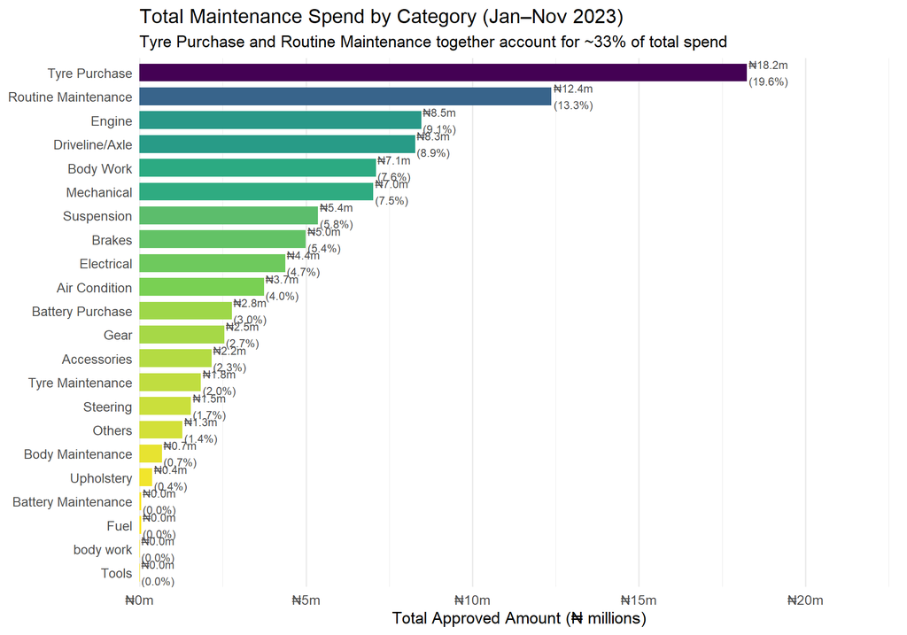

```r
cat_spend <- maint %>%
  group_by(Maint_Cat) %>%
  summarise(Total = sum(Amount, na.rm=TRUE),
            Count = n(),
            Avg   = mean(Amount, na.rm=TRUE)) %>%
  arrange(desc(Total)) %>%
  mutate(Pct = Total/sum(Total)*100,
         Maint_Cat = fct_reorder(Maint_Cat, Total))

ggplot(cat_spend, aes(x = Maint_Cat, y = Total/1e6, fill = Total)) +
  geom_col(width = 0.75) +
  geom_text(aes(label = sprintf("₦%.1fm\n(%.1f%%)", Total/1e6, Pct)),
            hjust = -0.05, size = 3.2, colour = "grey30") +
  coord_flip() +
  scale_fill_viridis_c(option = "D", direction = -1, guide = "none") +
  scale_y_continuous(labels = label_comma(suffix = "m", prefix = "₦"),
                     expand = expansion(mult = c(0, 0.25))) +
  labs(title = "Total Maintenance Spend by Category (Jan–Nov 2023)",
       subtitle = "Tyre Purchase and Routine Maintenance together account for ~33% of total spend",
       x = NULL, y = "Total Approved Amount (₦ millions)") +
  theme_minimal(base_size = 13) +
  theme(panel.grid.major.y = element_blank())
```

**Python**

```python
cat_spend = (maint.groupby("Maint_Cat")["Amount"]
             .agg(Total="sum", Count="count", Avg="mean")
             .reset_index()
             .sort_values("Total"))

fig, ax = plt.subplots(figsize=(10, 7))
colors = plt.cm.viridis(np.linspace(0.2, 0.9, len(cat_spend)))
bars = ax.barh(cat_spend["Maint_Cat"], cat_spend["Total"]/1e6, color=colors)

total_sum = cat_spend["Total"].sum()
for i, (val, pct) in enumerate(zip(cat_spend["Total"], cat_spend["Total"]/total_sum*100)):
    ax.text(val/1e6 + 0.1, i, f"₦{val/1e6:.1f}m ({pct:.1f}%)", va="center", fontsize=9)

ax.set_xlabel("Total Approved Amount (₦ millions)")
ax.set_title("Total Maintenance Spend by Category (Jan–Nov 2023)", fontsize=14, fontweight="bold")
ax.set_xlim(0, cat_spend["Total"].max()/1e6 * 1.35)
```

```
(0.0, 24.626565000000003)
```

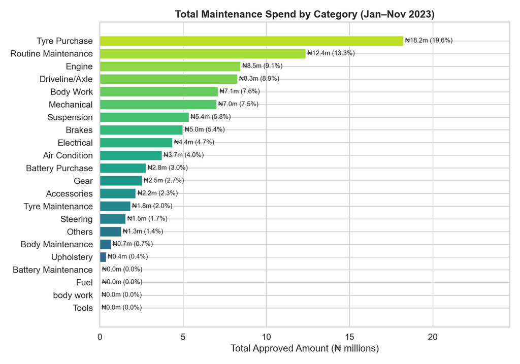

```python
plt.tight_layout()
plt.savefig("cat_spend.png", dpi=150, bbox_inches="tight")
plt.show()
```

# 6. Data Visualisation

> **Technique 2 | Chapter 5 — Grammar of graphics, chart selection, storytelling with data**

The five plots below tell a single coherent story: **maintenance costs at KK Leasing are concentrated in a few high-risk categories, driven by an ageing Toyota-dominated fleet, and peak in the mid-year months — suggesting a structural vulnerability in current maintenance governance.**

## 6.1 Monthly Expenditure Trend

**R**

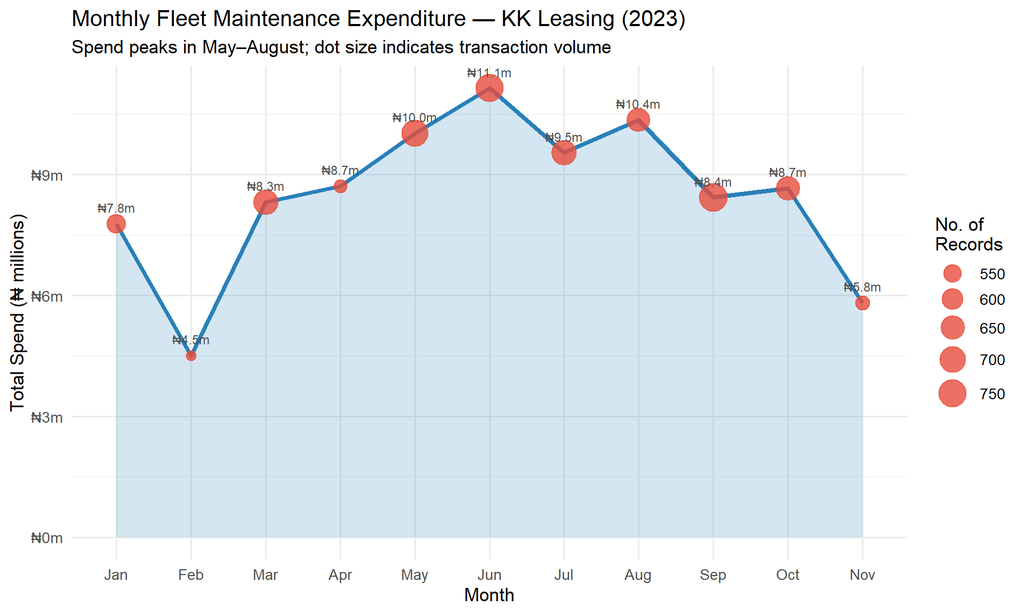

```r
monthly_spend <- maint %>%
  group_by(Month) %>%
  summarise(Total = sum(Amount, na.rm=TRUE), Count = n()) %>%
  mutate(CumTotal = cumsum(Total))

ggplot(monthly_spend, aes(x = Month, y = Total/1e6, group = 1)) +
  geom_area(fill = "#2980b9", alpha = 0.2) +
  geom_line(colour = "#2980b9", linewidth = 1.5) +
  geom_point(aes(size = Count), colour = "#e74c3c", alpha = 0.8) +
  geom_text(aes(label = sprintf("₦%.1fm", Total/1e6)),
            vjust = -1.2, size = 3.2, colour = "grey30") +
  scale_y_continuous(labels = label_comma(suffix = "m", prefix = "₦")) +
  scale_size_continuous(name = "No. of\nRecords", range = c(3, 9)) +
  labs(title = "Monthly Fleet Maintenance Expenditure — KK Leasing (2023)",
       subtitle = "Spend peaks in May–August; dot size indicates transaction volume",
       x = "Month", y = "Total Spend (₦ millions)") +
  theme_minimal(base_size = 13)
```

**Python**

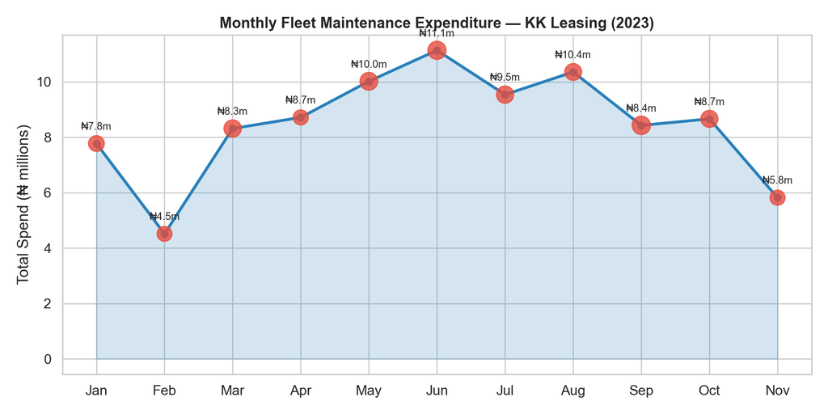

```python
monthly = (maint.groupby("Month", observed=True)["Amount"]
           .agg(Total="sum", Count="count").reset_index())

fig, ax = plt.subplots(figsize=(10, 5))
ax.fill_between(range(len(monthly)), monthly["Total"]/1e6, alpha=0.2, color="#2980b9")
ax.plot(range(len(monthly)), monthly["Total"]/1e6, color="#2980b9", lw=2.5, marker="o")
sc = ax.scatter(range(len(monthly)), monthly["Total"]/1e6,
                s=monthly["Count"]/3, color="#e74c3c", alpha=0.8, zorder=5)

for i, row in monthly.iterrows():
    ax.annotate(f"₦{row['Total']/1e6:.1f}m", (i, row["Total"]/1e6),
                textcoords="offset points", xytext=(0, 12), ha="center", fontsize=9)

ax.set_xticks(range(len(monthly)))
ax.set_xticklabels(monthly["Month"].tolist())
ax.set_ylabel("Total Spend (₦ millions)")
ax.set_title("Monthly Fleet Maintenance Expenditure — KK Leasing (2023)",
             fontsize=13, fontweight="bold")
plt.tight_layout()
plt.savefig("monthly.png", dpi=150, bbox_inches="tight")
plt.show()
```